# Predicting the risk of pregnancy

Celumusa Fakudze

2025-10-22

Data loading and examination

```r
library(readr)
data <- read_csv("C:/Users/Fakudze/Downloads/archive (31).zip")
View(data)
```

```r
library(skimr)
skim(data)
```

Data summary

| Name | data |
| --- | --- |
| Number of rows | 1205 |
| Number of columns | 12 |
| _______________________ |  |
| Column type frequency: |  |
| character | 1 |
| numeric | 11 |
| ________________________ |  |
| Group variables | None |

**Variable type: character**

| skim_variable | n_missing | complete_rate | min | max | empty | n_unique | whitespace |
| --- | --- | --- | --- | --- | --- | --- | --- |
| Risk Level | 18 | 0.99 | 3 | 4 | 0 | 2 | 0 |

**Variable type: numeric**

| skim_variable | n_missing | complete_rate | mean | sd | p0 | p25 | p50 | p75 | p100 | hist |
| --- | --- | --- | --- | --- | --- | --- | --- | --- | --- | --- |
| Age | 0 | 1.00 | 27.48 | 9.20 | 10 | 21.00 | 25.0 | 31.0 | 65 | ▅▇▂▁▁ |
| Systolic BP | 5 | 1.00 | 116.82 | 18.72 | 70 | 100.00 | 120.0 | 130.0 | 200 | ▂▇▃▁▁ |
| Diastolic | 4 | 1.00 | 77.17 | 14.31 | 40 | 65.00 | 80.0 | 90.0 | 140 | ▃▇▅▁▁ |
| BS | 2 | 1.00 | 7.50 | 3.05 | 3 | 6.00 | 6.9 | 7.9 | 19 | ▅▇▁▁▁ |
| Body Temp | 0 | 1.00 | 98.40 | 1.09 | 97 | 98.00 | 98.0 | 98.0 | 103 | ▇▁▁▁▁ |
| BMI | 18 | 0.99 | 23.32 | 3.88 | 0 | 20.45 | 23.0 | 25.0 | 37 | ▁▁▇▇▁ |
| Previous Complications | 2 | 1.00 | 0.18 | 0.38 | 0 | 0.00 | 0.0 | 0.0 | 1 | ▇▁▁▁▂ |
| Preexisting Diabetes | 2 | 1.00 | 0.29 | 0.45 | 0 | 0.00 | 0.0 | 1.0 | 1 | ▇▁▁▁▃ |
| Gestational Diabetes | 0 | 1.00 | 0.12 | 0.32 | 0 | 0.00 | 0.0 | 0.0 | 1 | ▇▁▁▁▁ |
| Mental Health | 0 | 1.00 | 0.33 | 0.47 | 0 | 0.00 | 0.0 | 1.0 | 1 | ▇▁▁▁▅ |
| Heart Rate | 2 | 1.00 | 75.82 | 7.23 | 58 | 70.00 | 76.0 | 80.0 | 92 | ▁▃▇▂▂ |

# Data cleaning

Reviewing Age variable(Checking for outliers and replacing them)

```r
library(tidyverse)
```

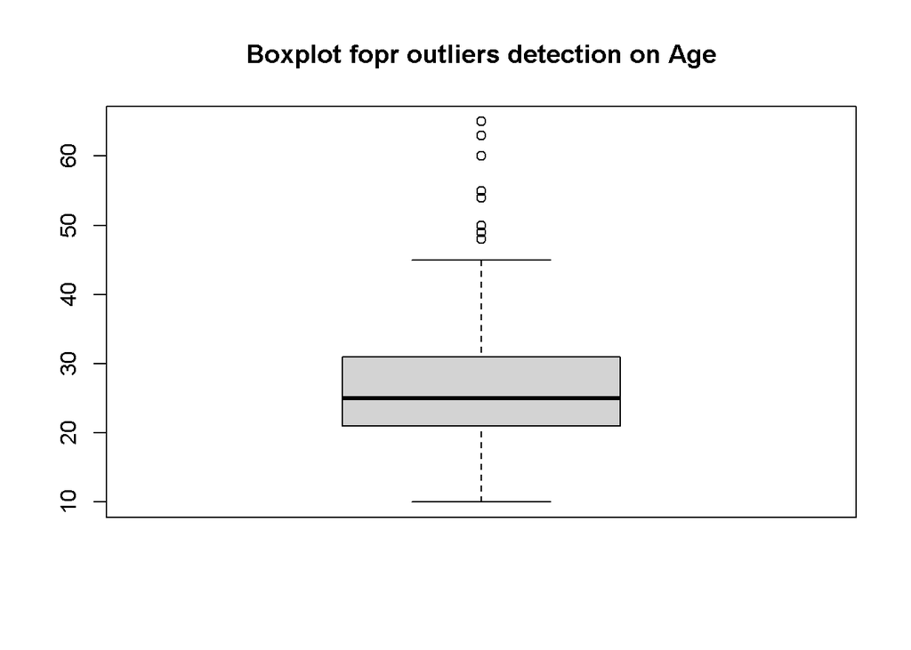

```r
boxplot(data$Age, main = "Boxplot fopr outliers detection on Age")
```

## Cleaning Systolic BP variable (checking for outliers and replacing them

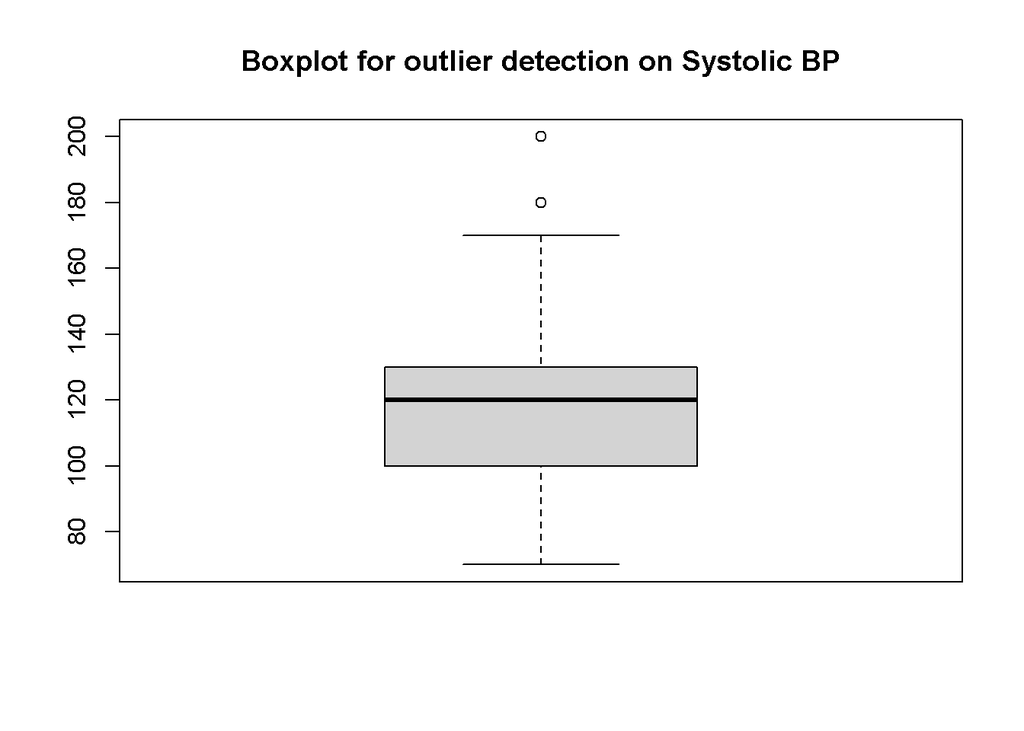

```r
boxplot(data$`Systolic BP`, main = "Boxplot for outlier detection on Systolic BP")
```

```r
data <- data %>%
         mutate(`Systolic BP` = if_else(is.na(`Systolic BP`),
                                        median(`Systolic BP`, na.rm = T),
                                        `Systolic BP`))
```

## Cleaning Diastolic variable (checking for outliers and replacing them

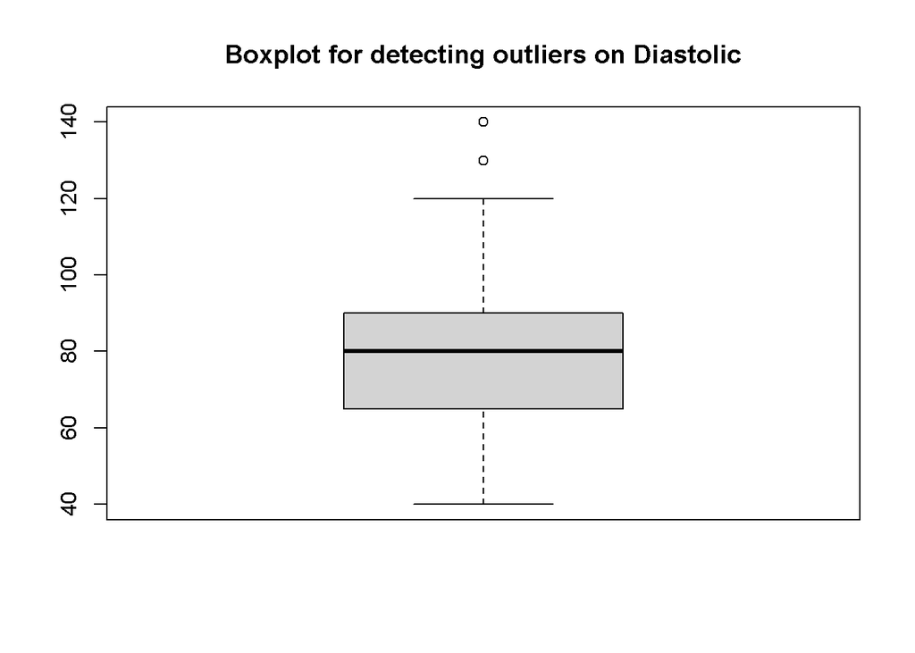

```r
boxplot(data$Diastolic, main = "Boxplot for detecting outliers on Diastolic")
```

```r
data <- data %>%
         mutate(Diastolic = if_else(is.na(Diastolic),
                                    median(Diastolic, na.rm = T),
                                    Diastolic))
```

## Cleaning BS variable (checking for outliers and replacing them)

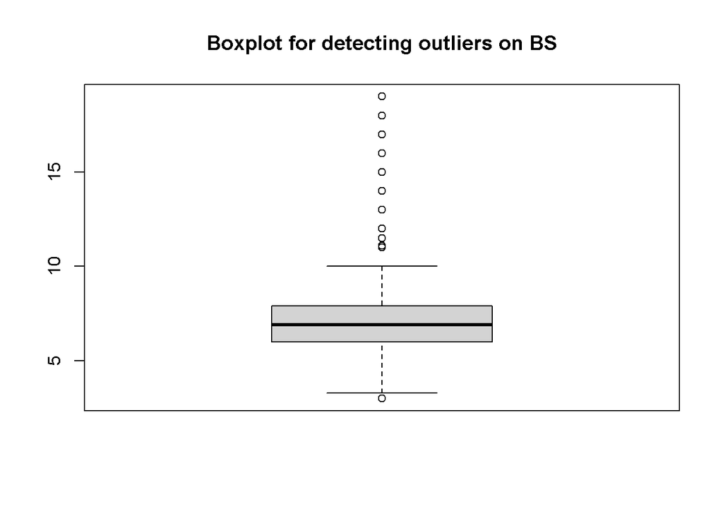

```r
boxplot(data$BS, main = "Boxplot for detecting outliers on BS")
```

```r
data <- data %>%
         mutate(BS = if_else(is.na(BS),
                             median(BS, na.rm = T),
                             BS))
```

## Cleaning BMI variable (checking for outliers and replacing them)

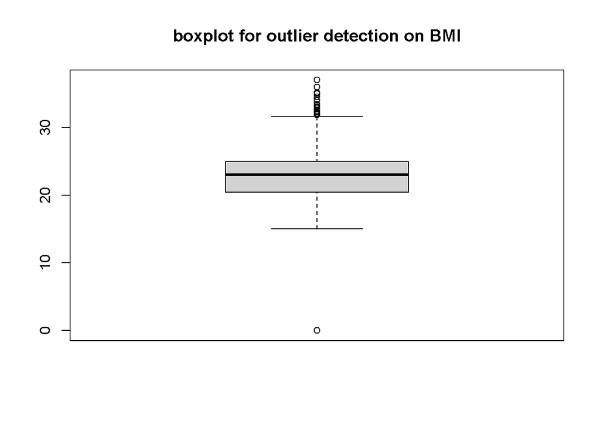

```r
boxplot(data$BMI, main = "boxplot for outlier detection on BMI")
```

```r
data <- data %>%
  mutate(BMI = if_else(is.na(BMI),
                       median(BMI),
                       BMI))
```

## Cleaning Heart Rate variable (checking for outliers and replacing them)

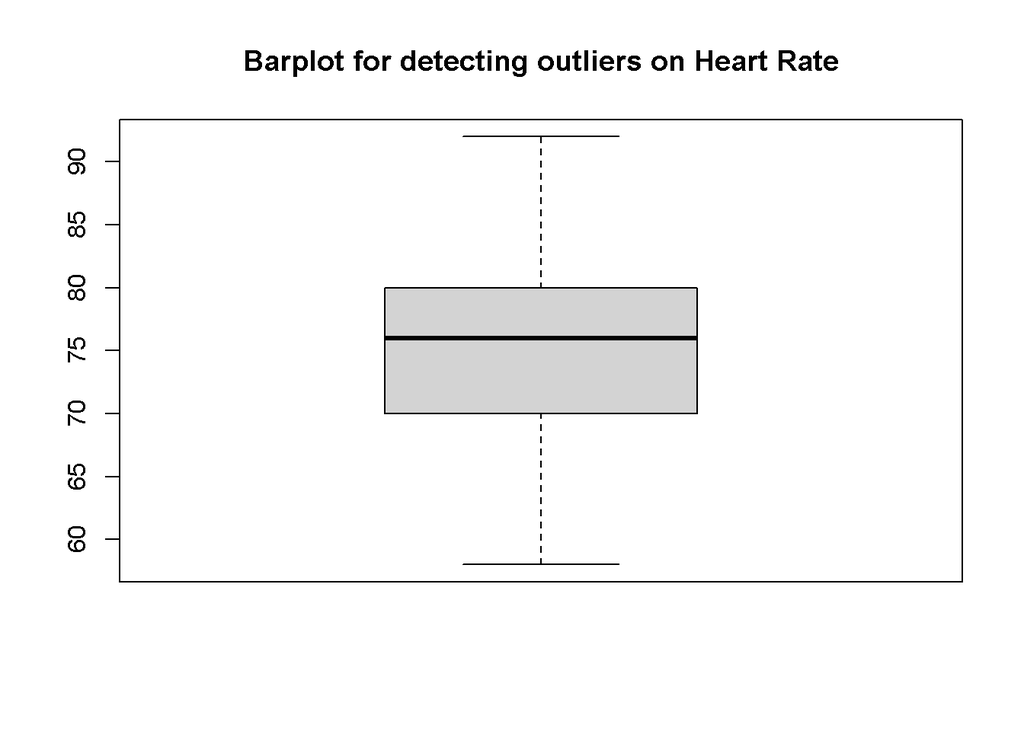

```r
boxplot(data$`Heart Rate`, main = "Barplot for detecting outliers on Heart Rate")
```

```r
data <- data %>%
         mutate(`Heart Rate` = if_else(is.na(`Heart Rate`),
                                       mean(`Heart Rate`, na.rm = T),
                                     `Heart Rate`))
```

### Recoding character indicators and converting to factor

```r
library(dplyr)
data <- data %>%
         mutate(across(c(`Preexisting Diabetes`, `Gestational Diabetes`,
                         `Mental Health`, `Previous Complications`),
                       as.factor))
data <- data %>%
  mutate(`Risk Level` = factor(`Risk Level`, levels = c("Low", "High")))
```

## Replacing Missing values with Unknown in factor variables

```r
library(forcats)
data <- data %>%
         mutate(across(c(`Preexisting Diabetes`, `Gestational Diabetes`,
                         `Mental Health`, `Previous Complications`), ~ fct_explicit_na(as.factor(.), na_level
                                                          = "Unknown")))
```

## Extracting clean data for analysis

```r
clean_data <- data %>%
         na.omit()

skim(clean_data)
```

Data summary

| Name | clean_data |
| --- | --- |
| Number of rows | 1173 |
| Number of columns | 12 |
| _______________________ |  |
| Column type frequency: |  |
| factor | 5 |
| numeric | 7 |
| ________________________ |  |
| Group variables | None |

**Variable type: factor**

| skim_variable | n_missing | complete_rate | ordered | n_unique | top_counts |
| --- | --- | --- | --- | --- | --- |
| Previous Complications | 0 | 1 | FALSE | 3 | 0: 963, 1: 209, Unk: 1 |
| Preexisting Diabetes | 0 | 1 | FALSE | 3 | 0: 831, 1: 341, Unk: 1 |
| Gestational Diabetes | 0 | 1 | FALSE | 2 | 0: 1036, 1: 137 |
| Mental Health | 0 | 1 | FALSE | 2 | 0: 781, 1: 392 |
| Risk Level | 0 | 1 | FALSE | 2 | Low: 706, Hig: 467 |

**Variable type: numeric**

| skim_variable | n_missing | complete_rate | mean | sd | p0 | p25 | p50 | p75 | p100 | hist |
| --- | --- | --- | --- | --- | --- | --- | --- | --- | --- | --- |
| Age | 0 | 1 | 27.52 | 9.25 | 10 | 21 | 25.0 | 32.0 | 65 | ▅▇▂▁▁ |
| Systolic BP | 0 | 1 | 116.85 | 18.69 | 70 | 100 | 120.0 | 130.0 | 200 | ▂▇▃▁▁ |
| Diastolic | 0 | 1 | 77.26 | 14.29 | 40 | 65 | 80.0 | 90.0 | 140 | ▃▇▅▁▁ |
| BS | 0 | 1 | 7.52 | 3.06 | 3 | 6 | 6.9 | 7.9 | 19 | ▅▇▁▁▁ |
| Body Temp | 0 | 1 | 98.39 | 1.08 | 97 | 98 | 98.0 | 98.0 | 103 | ▇▁▁▁▁ |
| BMI | 0 | 1 | 23.34 | 3.88 | 0 | 21 | 23.0 | 25.0 | 37 | ▁▁▇▇▂ |
| Heart Rate | 0 | 1 | 75.80 | 7.22 | 58 | 70 | 76.0 | 80.0 | 92 | ▁▃▇▂▂ |

## Checking for class imbalance on Risk Level

```r
table(clean_data$`Risk Level`)
```

```
##
##  Low High
##  706  467
```

# Data Analysis

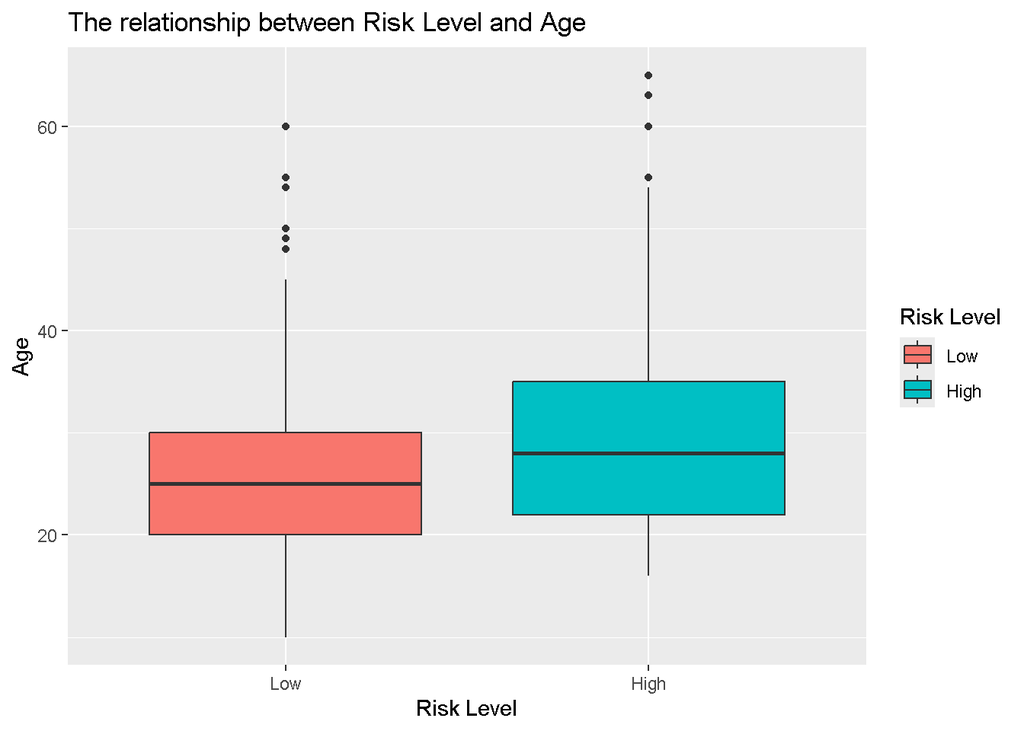

```r
ggplot(clean_data)+
  geom_boxplot(mapping = aes(`Risk Level`, Age, fill = `Risk Level`))+
  labs(title = "The relationship between Risk Level and Age")
```

```r
model_Age <- glm(`Risk Level` ~ Age, data = clean_data,
                 family = binomial)
summary(model_Age)
```

```
##
## Call:
## glm(formula = `Risk Level` ~ Age, family = binomial, data = clean_data)
##
## Coefficients:
##              Estimate Std. Error z value Pr(>|z|)
## (Intercept) -1.624897   0.196880  -8.253  < 2e-16 ***
## Age          0.043679   0.006735   6.485 8.86e-11 ***
## ---
## Signif. codes:  0 '***' 0.001 '**' 0.01 '*' 0.05 '.' 0.1 ' ' 1
##
## (Dispersion parameter for binomial family taken to be 1)
##
##     Null deviance: 1577.1  on 1172  degrees of freedom
## Residual deviance: 1532.4  on 1171  degrees of freedom
## AIC: 1536.4
##
## Number of Fisher Scoring iterations: 4
```

The boxplot visual shows that woman from the High Risk category have higher median Age value than those from the Low Risk category. The logistic model reveals that for every one year increase in Age, the log-odds of a woman being in the High Risk category increases by 0.0437. Age is a statistically significant predictor of Risk Level.

## Does Blood Sugar (BS) signicantly predict Risk Level?

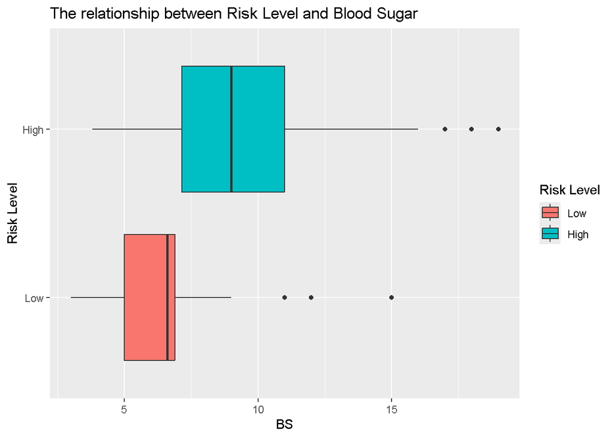

```r
ggplot(clean_data)+
  geom_boxplot(mapping = aes(`Risk Level`, BS, fill = `Risk Level`))+
  coord_flip()+
  labs(title = "The relationship between Risk Level and Blood Sugar")
```

```r
model_BS <- glm(`Risk Level`~ BS,
                data = clean_data, family = binomial)
summary(model_BS)
```

```
##
## Call:
## glm(formula = `Risk Level` ~ BS, family = binomial, data = clean_data)
##
## Coefficients:
##             Estimate Std. Error z value Pr(>|z|)
## (Intercept) -7.24639    0.48309  -15.00   <2e-16 ***
## BS           0.93987    0.06729   13.97   <2e-16 ***
## ---
## Signif. codes:  0 '***' 0.001 '**' 0.01 '*' 0.05 '.' 0.1 ' ' 1
##
## (Dispersion parameter for binomial family taken to be 1)
##
##     Null deviance: 1577.1  on 1172  degrees of freedom
## Residual deviance: 1006.4  on 1171  degrees of freedom
## AIC: 1010.4
##
## Number of Fisher Scoring iterations: 6
```

The box plot reveals that the High Risk group has the highest median Blood Sugar values than the Low Risk Group. The results from this model reveals that Blood Sugar is a statistical significant predictor of Risk Level. The coefficient of 0.93987 means that as Blood Sugar increases, the odds of being in the High Risk level increases.

## What is the relationship between BMI and Risk Level?

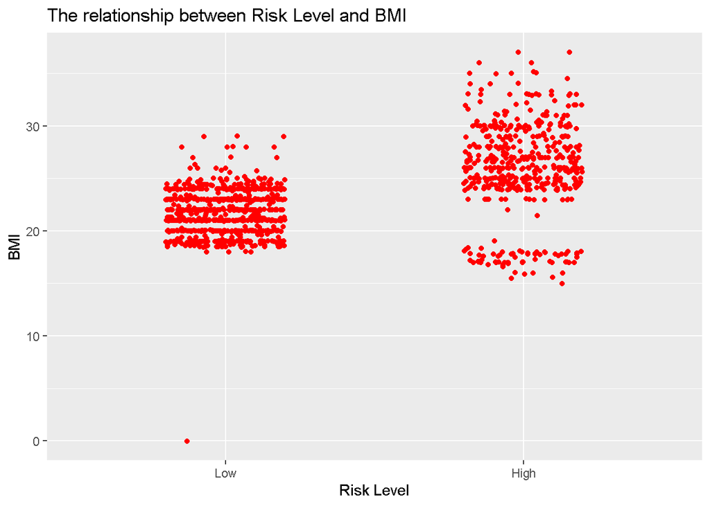

```r
ggplot(clean_data)+
  geom_jitter(mapping = aes(`Risk Level`, BMI), width = 0.2, color = "red")+
  labs(title = "The relationship between Risk Level and BMI")
```

```r
model_BMI <- glm(`Risk Level`~ BMI, data = clean_data,
                 family = binomial)

summary(model_BMI)
```

```
##
## Call:
## glm(formula = `Risk Level` ~ BMI, family = binomial, data = clean_data)
##
## Coefficients:
##             Estimate Std. Error z value Pr(>|z|)
## (Intercept) -9.33491    0.58999  -15.82   <2e-16 ***
## BMI          0.37841    0.02479   15.27   <2e-16 ***
## ---
## Signif. codes:  0 '***' 0.001 '**' 0.01 '*' 0.05 '.' 0.1 ' ' 1
##
## (Dispersion parameter for binomial family taken to be 1)
##
##     Null deviance: 1577.1  on 1172  degrees of freedom
## Residual deviance: 1208.2  on 1171  degrees of freedom
## AIC: 1212.2
##
## Number of Fisher Scoring iterations: 4
```

## Do Previous Clomplications increase the likelihood of High Risk Level

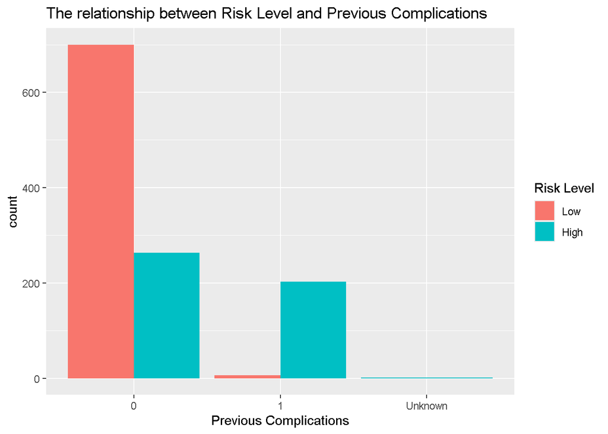

```r
ggplot(clean_data)+
  geom_bar(mapping = aes(`Previous Complications`, fill = `Risk Level`),
           position = "dodge")+
  labs(title = "The relationship between Risk Level and Previous Complications")
```

```r
model_PC <- glm(`Risk Level`~ `Previous Complications`, data = clean_data,
                family = binomial)

summary(model_PC)
```

```
##
## Call:
## glm(formula = `Risk Level` ~ `Previous Complications`, family = binomial,
##     data = clean_data)
##
## Coefficients:
##                                  Estimate Std. Error z value Pr(>|z|)
## (Intercept)                      -0.97893    0.07232 -13.535   <2e-16 ***
## `Previous Complications`1         4.50037    0.42050  10.702   <2e-16 ***
## `Previous Complications`Unknown  14.54499  535.41117   0.027    0.978
## ---
## Signif. codes:  0 '***' 0.001 '**' 0.01 '*' 0.05 '.' 0.1 ' ' 1
##
## (Dispersion parameter for binomial family taken to be 1)
##
##     Null deviance: 1577.1  on 1172  degrees of freedom
## Residual deviance: 1183.7  on 1170  degrees of freedom
## AIC: 1189.7
##
## Number of Fisher Scoring iterations: 12
```

The estimate of 4.50037 means that, compared to the reference group (Previous Complications 0), the log-odds of being in the High Risk Level increase by 4.50037 when previous Complications is 1. Also, The estimate of 14.54499 means that, compared to the reference group (Previous Complications 0), the log-odds of being in the High Risk Level increase by 14.54499 when previous Complications is Unknown.

## How do Heart Rate and Systolic BP together influence Risk Level

```r
model_HS <- glm(`Risk Level`~ `Heart Rate` + `Systolic BP`, data = clean_data,
                family = binomial)

summary(model_HS)
```

```
##
## Call:
## glm(formula = `Risk Level` ~ `Heart Rate` + `Systolic BP`, family = binomial,
##     data = clean_data)
##
## Coefficients:
##                 Estimate Std. Error z value Pr(>|z|)
## (Intercept)   -17.272401   1.087241 -15.886  < 2e-16 ***
## `Heart Rate`    0.168549   0.012061  13.975  < 2e-16 ***
## `Systolic BP`   0.034087   0.004165   8.185 2.73e-16 ***
## ---
## Signif. codes:  0 '***' 0.001 '**' 0.01 '*' 0.05 '.' 0.1 ' ' 1
##
## (Dispersion parameter for binomial family taken to be 1)
##
##     Null deviance: 1577.1  on 1172  degrees of freedom
## Residual deviance: 1202.0  on 1170  degrees of freedom
## AIC: 1208
##
## Number of Fisher Scoring iterations: 4
```

The results from this model reveals that a pregnant woman’s Heart Rate is a statistical significant predictor of Risk Level. The positive coefficient of 0.168549 means that as Heart Rate increases, the odds of being in the High Risk level also increases. One Unit increase in Heart Rate of maternal woman, the likelihood of her being in the High Risk category is 0.168549.

The results from this model reveals that a pregnant woman’s Systolic BP is a statistical significant predictor of Risk Level. The positive coefficient of 0.034087 means that as Systolic BP increases, the odds of being in the High Risk level also increases. One Unit increase in Systolic BP of maternal woman, the likelihood of her being in the High Risk category is 0.034087.

## Which factors among Age, BS, BMI, and Mental Health best predict Risk Level?

```r
library(caret)
library(randomForest)
model <- glm(`Risk Level`~ Age + BMI + BS +`Mental Health`,
             data = clean_data, family = binomial)

summary(model)
```

```
##
## Call:
## glm(formula = `Risk Level` ~ Age + BMI + BS + `Mental Health`,
##     family = binomial, data = clean_data)
##
## Coefficients:
##                   Estimate Std. Error z value Pr(>|z|)
## (Intercept)      -10.42337    0.79627 -13.090  < 2e-16 ***
## Age               -0.10490    0.01585  -6.619 3.61e-11 ***
## BMI                0.24158    0.03146   7.678 1.61e-14 ***
## BS                 0.83782    0.07604  11.018  < 2e-16 ***
## `Mental Health`1   2.93717    0.22073  13.307  < 2e-16 ***
## ---
## Signif. codes:  0 '***' 0.001 '**' 0.01 '*' 0.05 '.' 0.1 ' ' 1
##
## (Dispersion parameter for binomial family taken to be 1)
##
##     Null deviance: 1577.1  on 1172  degrees of freedom
## Residual deviance:  637.5  on 1168  degrees of freedom
## AIC: 647.5
##
## Number of Fisher Scoring iterations: 6
```

```r
model_best_predict <- train(`Risk Level`~ Age + BMI + BS + `Mental Health`,
                            data = clean_data, model = "glm")
varImp(model_best_predict)
```

```
## rf variable importance
##
##                  Overall
## BMI               100.00
## BS                 78.29
## `Mental Health`1   26.30
## Age                 0.00
```

Maternal woman’s Body Mass Index and Blood Sugar are the best predictors of Maternal Risk Level on women while Mental Health and the women’ Age are the least to none predictors.